# Predicting Chronic Kidney Disease Using Machine Learning: A Comparative Analysis

Bhagyesh Vaze

```r
data <- read.csv("https://drive.google.com/uc?id=1MHp35VxG_NI0R-3_IuO6CCDvjsrtAPf8&export=download")

head(data)
```

|  | bp..Diastolic. | bp.limit | sg | al | class | rbc | su | pc | pcc | ba | bgr | bu | sod | sc | pot | hemo | pcv | rbcc | wbcc | htn | dm | cad | appet | pe | ane | grf | stage | affected | age |
| --- | --- | --- | --- | --- | --- | --- | --- | --- | --- | --- | --- | --- | --- | --- | --- | --- | --- | --- | --- | --- | --- | --- | --- | --- | --- | --- | --- | --- | --- |
| 1 | discrete | discrete | discrete | discrete | discrete | discrete | discrete | discrete | discrete | discrete | discrete | discrete | discrete | discrete | discrete | discrete | discrete | discrete | discrete | discrete | discrete | discrete | discrete | discrete | discrete | discrete | discrete | discrete | discrete |
| 2 |  |  |  |  |  |  |  |  |  |  |  |  |  |  |  |  |  |  |  |  |  |  |  |  |  |  |  | class | meta |
| 3 | 0 | 0 | 1.019 - 1.021 | 1 - 1 | ckd | 0 | < 0 | 0 | 0 | 0 | < 112 | < 48.1 | 138 - 143 | < 3.65 | < 7.31 | 11.3 - 12.6 | 33.5 - 37.4 | 4.46 - 5.05 | 7360 - 9740 | 0 | 0 | 0 | 0 | 0 | 0 | ≥ 227.944 | s1 | 1 | < 12 |
| 4 | 0 | 0 | 1.009 - 1.011 | < 0 | ckd | 0 | < 0 | 0 | 0 | 0 | 112 - 154 | < 48.1 | 133 - 138 | < 3.65 | < 7.31 | 11.3 - 12.6 | 33.5 - 37.4 | 4.46 - 5.05 | 12120 - 14500 | 0 | 0 | 0 | 0 | 0 | 0 | ≥ 227.944 | s1 | 1 | < 12 |
| 5 | 0 | 0 | 1.009 - 1.011 | ≥ 4 | ckd | 1 | < 0 | 1 | 0 | 1 | < 112 | 48.1 - 86.2 | 133 - 138 | < 3.65 | < 7.31 | 8.7 - 10 | 29.6 - 33.5 | 4.46 - 5.05 | 14500 - 16880 | 0 | 0 | 0 | 1 | 0 | 0 | 127.281 - 152.446 | s1 | 1 | < 12 |
| 6 | 1 | 1 | 1.009 - 1.011 | 3 - 3 | ckd | 0 | < 0 | 0 | 0 | 0 | 112 - 154 | < 48.1 | 133 - 138 | < 3.65 | < 7.31 | 13.9 - 15.2 | 41.3 - 45.2 | 4.46 - 5.05 | 7360 - 9740 | 0 | 0 | 0 | 0 | 0 | 0 | 127.281 - 152.446 | s1 | 1 | < 12 |

```r
df<- data[-c(1,2), ]

rownames(df) <- NULL

dim(df)
```

```
## [1] 200  29
```

```r
head(df)
```

|  | bp..Diastolic. | bp.limit | sg | al | class | rbc | su | pc | pcc | ba | bgr | bu | sod | sc | pot | hemo | pcv | rbcc | wbcc | htn | dm | cad | appet | pe | ane | grf | stage | affected | age |
| --- | --- | --- | --- | --- | --- | --- | --- | --- | --- | --- | --- | --- | --- | --- | --- | --- | --- | --- | --- | --- | --- | --- | --- | --- | --- | --- | --- | --- | --- |
| 1 | 0 | 0 | 1.019 - 1.021 | 1 - 1 | ckd | 0 | < 0 | 0 | 0 | 0 | < 112 | < 48.1 | 138 - 143 | < 3.65 | < 7.31 | 11.3 - 12.6 | 33.5 - 37.4 | 4.46 - 5.05 | 7360 - 9740 | 0 | 0 | 0 | 0 | 0 | 0 | ≥ 227.944 | s1 | 1 | < 12 |
| 2 | 0 | 0 | 1.009 - 1.011 | < 0 | ckd | 0 | < 0 | 0 | 0 | 0 | 112 - 154 | < 48.1 | 133 - 138 | < 3.65 | < 7.31 | 11.3 - 12.6 | 33.5 - 37.4 | 4.46 - 5.05 | 12120 - 14500 | 0 | 0 | 0 | 0 | 0 | 0 | ≥ 227.944 | s1 | 1 | < 12 |
| 3 | 0 | 0 | 1.009 - 1.011 | ≥ 4 | ckd | 1 | < 0 | 1 | 0 | 1 | < 112 | 48.1 - 86.2 | 133 - 138 | < 3.65 | < 7.31 | 8.7 - 10 | 29.6 - 33.5 | 4.46 - 5.05 | 14500 - 16880 | 0 | 0 | 0 | 1 | 0 | 0 | 127.281 - 152.446 | s1 | 1 | < 12 |
| 4 | 1 | 1 | 1.009 - 1.011 | 3 - 3 | ckd | 0 | < 0 | 0 | 0 | 0 | 112 - 154 | < 48.1 | 133 - 138 | < 3.65 | < 7.31 | 13.9 - 15.2 | 41.3 - 45.2 | 4.46 - 5.05 | 7360 - 9740 | 0 | 0 | 0 | 0 | 0 | 0 | 127.281 - 152.446 | s1 | 1 | < 12 |
| 5 | 0 | 0 | 1.015 - 1.017 | < 0 | ckd | 0 | < 0 | 0 | 0 | 0 | 154 - 196 | < 48.1 | 133 - 138 | < 3.65 | < 7.31 | 13.9 - 15.2 | 37.4 - 41.3 | 5.05 - 5.64 | 7360 - 9740 | 0 | 1 | 0 | 1 | 1 | 0 | 127.281 - 152.446 | s1 | 1 | 12 - 20 |
| 6 | 1 | 1 | ≥ 1.023 | < 0 | notckd | 0 | < 0 | 0 | 0 | 0 | < 112 | < 48.1 | 133 - 138 | < 3.65 | < 7.31 | ≥ 16.5 | ≥ 49.1 | 5.05 - 5.64 | 4980 - 7360 | 0 | 0 | 0 | 0 | 0 | 0 | 102.115 - 127.281 | s1 | 0 | 12 - 20 |

```r
str(df)
```

```
## 'data.frame':    200 obs. of  29 variables:
##  $ bp..Diastolic.: chr  "0" "0" "0" "1" ...
##  $ bp.limit      : chr  "0" "0" "0" "1" ...
##  $ sg            : chr  "1.019 - 1.021" "1.009 - 1.011" "1.009 - 1.011" "1.009 - 1.011" ...
##  $ al            : chr  "1 - 1" "< 0" "≥ 4" "3 - 3" ...
##  $ class         : chr  "ckd" "ckd" "ckd" "ckd" ...
##  $ rbc           : chr  "0" "0" "1" "0" ...
##  $ su            : chr  "< 0" "< 0" "< 0" "< 0" ...
##  $ pc            : chr  "0" "0" "1" "0" ...
##  $ pcc           : chr  "0" "0" "0" "0" ...
##  $ ba            : chr  "0" "0" "1" "0" ...
##  $ bgr           : chr  "< 112" "112 - 154" "< 112" "112 - 154" ...
##  $ bu            : chr  "< 48.1" "< 48.1" "48.1 - 86.2" "< 48.1" ...
##  $ sod           : chr  "138 - 143" "133 - 138" "133 - 138" "133 - 138" ...
##  $ sc            : chr  "< 3.65" "< 3.65" "< 3.65" "< 3.65" ...
##  $ pot           : chr  "< 7.31" "< 7.31" "< 7.31" "< 7.31" ...
##  $ hemo          : chr  "11.3 - 12.6" "11.3 - 12.6" "8.7 - 10" "13.9 - 15.2" ...
##  $ pcv           : chr  "33.5 - 37.4" "33.5 - 37.4" "29.6 - 33.5" "41.3 - 45.2" ...
##  $ rbcc          : chr  "4.46 - 5.05" "4.46 - 5.05" "4.46 - 5.05" "4.46 - 5.05" ...
##  $ wbcc          : chr  "7360 - 9740" "12120 - 14500" "14500 - 16880" "7360 - 9740" ...
##  $ htn           : chr  "0" "0" "0" "0" ...
##  $ dm            : chr  "0" "0" "0" "0" ...
##  $ cad           : chr  "0" "0" "0" "0" ...
##  $ appet         : chr  "0" "0" "1" "0" ...
##  $ pe            : chr  "0" "0" "0" "0" ...
##  $ ane           : chr  "0" "0" "0" "0" ...
##  $ grf           : chr  "≥ 227.944" "≥ 227.944" "127.281 - 152.446" "127.281 - 152.446" ...
##  $ stage         : chr  "s1" "s1" "s1" "s1" ...
##  $ affected      : chr  "1" "1" "1" "1" ...
##  $ age           : chr  "< 12" "< 12" "< 12" "< 12" ...
```

```r
lapply(df, unique)
```

```
## $bp..Diastolic.
## [1] "0" "1"
##
## $bp.limit
## [1] "0" "1" "2"
##
## $sg
## [1] "1.019 - 1.021" "1.009 - 1.011" "1.015 - 1.017" "≥ 1.023"
## [5] "< 1.007"
##
## $al
## [1] "1 - 1" "< 0"   "≥ 4"   "3 - 3" "2 - 2"
##
## $class
## [1] "ckd"    "notckd"
##
## $rbc
## [1] "0" "1"
##
## $su
## [1] "< 0"   "4 - 4" "2 - 2" "3 - 4" "1 - 2" "≥ 4"
##
## $pc
## [1] "0" "1"
##
## $pcc
## [1] "0" "1"
##
## $ba
## [1] "0" "1"
##
## $bgr
##  [1] "< 112"     "112 - 154" "154 - 196" "406 - 448" "238 - 280" "196 - 238"
##  [7] "≥ 448"     "280 - 322" "364 - 406" "322 - 364"
##
## $bu
## [1] "< 48.1"        "48.1 - 86.2"   "200.5 - 238.6" "124.3 - 162.4"
## [5] "86.2 - 124.3"  "162.4 - 200.5" "≥ 352.9"       "238.6 - 276.7"
##
## $sod
```

[output cut: 45 more lines]

```
## $grf
##  [1] "≥ 227.944"         "127.281 - 152.446" "102.115 - 127.281"
##  [4] "177.612 - 202.778" "26.6175 - 51.7832" "51.7832 - 76.949"
##  [7] "76.949 - 102.115"  "152.446 - 177.612" "202.778 - 227.944"
## [10] "< 26.6175"         " p "
##
## $stage
## [1] "s1" "s4" "s3" "s2" "s5"
##
## $affected
## [1] "1" "0"
##
## $age
##  [1] "< 12"    "12 - 20" "20 - 27" "27 - 35" "35 - 43" "43 - 51" "51 - 59"
##  [8] "59 - 66" "66 - 74" "≥ 74"
```

In this chunk, I mutate and inspect the original dataset.

```r
# Categorical Variable Distribution
table(df$class)
```

```
##
##    ckd notckd
##    128     72
```

```r
table(df$stage)
```

```
##
## s1 s2 s3 s4 s5
## 54 35 31 45 35
```

This chunk explores the distribution of class and stage as they are 2 prominent features.

```r
numeric_cols <- c("bp..Diastolic.", "bp.limit", "rbc", "pc", "pcc", "ba", "htn", "dm", "cad", "appet", "pe", "ane", "affected")
df[numeric_cols] <- lapply(df[numeric_cols], as.numeric)

df$class <- as.factor(df$class)

df$stage <- factor(df$stage, levels = c("s1", "s2", "s3", "s4", "s5"), ordered = TRUE)

range_cols <- c("sg", "al", "su", "bgr", "bu", "sod", "sc", "pot", "hemo", "pcv", "rbcc", "wbcc", "grf", "age")

transform_range_to_numeric <- function(x) {
  # Missing val handling
  if (is.na(x) || x == "") return(NA)

  # Range handling
  if (grepl(" - ", x)) {
    range_values <- as.numeric(strsplit(x, " - ")[[1]])
    return(mean(range_values, na.rm = TRUE))
  }

  # Handling < value by assuming 90% of the value
  if (grepl("^< ", x)) {
    return(as.numeric(gsub("< ", "", x)) * 0.9)
  }

  # Handling ≥ value by assuming 110% of the value
  if (grepl("^≥ ", x)) {
    return(as.numeric(gsub("≥ ", "", x)) * 1.1)
  }

  # Stage values handling
  if (grepl("^s[1-5]$", x)) {
    return(as.numeric(gsub("s", "", x)))
  }

  # Handling "p" in grf column
  if (x == " p ") return(NA)

  return(as.numeric(x))
}

df[range_cols] <- lapply(df[range_cols], function(col) sapply(col, transform_range_to_numeric))

head(df)
```

|  | bp..Diastolic. | bp.limit | sg | al | class | rbc | su | pc | pcc | ba | bgr | bu | sod | sc | pot | hemo | pcv | rbcc | wbcc | htn | dm | cad | appet | pe | ane | grf | stage | affected | age |
| --- | --- | --- | --- | --- | --- | --- | --- | --- | --- | --- | --- | --- | --- | --- | --- | --- | --- | --- | --- | --- | --- | --- | --- | --- | --- | --- | --- | --- | --- |
| 1 | 0 | 0 | 1.0200 | 1.0 | ckd | 0 | 0 | 0 | 0 | 0 | 100.8 | 43.29 | 140.5 | 3.285 | 6.579 | 11.95 | 35.45 | 4.755 | 8550 | 0 | 0 | 0 | 0 | 0 | 0 | 250.7384 | s1 | 1 | 10.8 |
| 2 | 0 | 0 | 1.0100 | 0.0 | ckd | 0 | 0 | 0 | 0 | 0 | 133.0 | 43.29 | 135.5 | 3.285 | 6.579 | 11.95 | 35.45 | 4.755 | 13310 | 0 | 0 | 0 | 0 | 0 | 0 | 250.7384 | s1 | 1 | 10.8 |
| 3 | 0 | 0 | 1.0100 | 4.4 | ckd | 1 | 0 | 1 | 0 | 1 | 100.8 | 67.15 | 135.5 | 3.285 | 6.579 | 9.35 | 31.55 | 4.755 | 15690 | 0 | 0 | 0 | 1 | 0 | 0 | 139.8635 | s1 | 1 | 10.8 |
| 4 | 1 | 1 | 1.0100 | 3.0 | ckd | 0 | 0 | 0 | 0 | 0 | 133.0 | 43.29 | 135.5 | 3.285 | 6.579 | 14.55 | 43.25 | 4.755 | 8550 | 0 | 0 | 0 | 0 | 0 | 0 | 139.8635 | s1 | 1 | 10.8 |
| 5 | 0 | 0 | 1.0160 | 0.0 | ckd | 0 | 0 | 0 | 0 | 0 | 175.0 | 43.29 | 135.5 | 3.285 | 6.579 | 14.55 | 39.35 | 5.345 | 8550 | 0 | 1 | 0 | 1 | 1 | 0 | 139.8635 | s1 | 1 | 16.0 |
| 6 | 1 | 1 | 1.1253 | 0.0 | notckd | 0 | 0 | 0 | 0 | 0 | 100.8 | 43.29 | 135.5 | 3.285 | 6.579 | 18.15 | 54.01 | 5.345 | 6170 | 0 | 0 | 0 | 0 | 0 | 0 | 114.6980 | s1 | 0 | 16.0 |

```r
str(df)
```

```
## 'data.frame':    200 obs. of  29 variables:
##  $ bp..Diastolic.: num  0 0 0 1 0 1 0 0 0 1 ...
##  $ bp.limit      : num  0 0 0 1 0 1 0 0 0 2 ...
##  $ sg            : num  1.02 1.01 1.01 1.01 1.02 ...
##  $ al            : num  1 0 4.4 3 0 0 3 0 0 4.4 ...
##  $ class         : Factor w/ 2 levels "ckd","notckd": 1 1 1 1 1 2 1 1 2 1 ...
##  $ rbc           : num  0 0 1 0 0 0 0 0 0 0 ...
##  $ su            : num  0 0 0 0 0 0 0 0 0 0 ...
##  $ pc            : num  0 0 1 0 0 0 0 0 0 1 ...
##  $ pcc           : num  0 0 0 0 0 0 0 0 0 1 ...
##  $ ba            : num  0 0 1 0 0 0 0 0 0 1 ...
##  $ bgr           : num  101 133 101 133 175 ...
##  $ bu            : num  43.3 43.3 67.2 43.3 43.3 ...
##  $ sod           : num  140 136 136 136 136 ...
##  $ sc            : num  3.29 3.29 3.29 3.29 3.29 ...
##  $ pot           : num  6.58 6.58 6.58 6.58 6.58 ...
##  $ hemo          : num  11.95 11.95 9.35 14.55 14.55 ...
##  $ pcv           : num  35.5 35.5 31.6 43.2 39.3 ...
##  $ rbcc          : num  4.75 4.75 4.75 4.75 5.34 ...
##  $ wbcc          : num  8550 13310 15690 8550 8550 ...
##  $ htn           : num  0 0 0 0 0 0 1 0 0 0 ...
##  $ dm            : num  0 0 0 0 1 0 1 0 0 0 ...
##  $ cad           : num  0 0 0 0 0 0 0 0 0 0 ...
##  $ appet         : num  0 0 1 0 1 0 0 0 0 0 ...
##  $ pe            : num  0 0 0 0 1 0 0 0 0 0 ...
##  $ ane           : num  0 0 0 0 0 0 0 0 0 1 ...
##  $ grf           : num  251 251 140 140 140 ...
##  $ stage         : Ord.factor w/ 5 levels "s1"<"s2"<"s3"<..: 1 1 1 1 1 1 1 4 4 3 ...
##  $ affected      : num  1 1 1 1 1 0 1 1 0 1 ...
##  $ age           : num  10.8 10.8 10.8 10.8 16 16 16 16 23.5 23.5 ...
```

In this chunk, I have transformed features as per their appropriate category. For the features which had ranges, I chose to use the mean as it is a standard approach to deal with range data. The original data doesn’t have missing values but grf has a value named “p” which gets converted to NA while transforming. We impute it in the next chunk.

```r
colSums(is.na(df))
```

```
## bp..Diastolic.       bp.limit             sg             al          class
##              0              0              0              0              0
##            rbc             su             pc            pcc             ba
##              0              0              0              0              0
##            bgr             bu            sod             sc            pot
##              0              0              0              0              0
##           hemo            pcv           rbcc           wbcc            htn
##              0              0              0              0              0
##             dm            cad          appet             pe            ane
##              0              0              0              0              0
##            grf          stage       affected            age
##              1              0              0              0
```

```r
impute_by_stage <- function(x, stage) {
  # Median for each stage
  stage_medians <- tapply(x, stage, median, na.rm = TRUE)

  # Impute based on resp stage
  for (s in unique(stage)) {
    x[is.na(x) & stage == s] <- stage_medians[as.character(s)]
  }

  return(x)
}

df$grf <- impute_by_stage(df$grf, df$stage)

colSums(is.na(df))
```

```
## bp..Diastolic.       bp.limit             sg             al          class
##              0              0              0              0              0
##            rbc             su             pc            pcc             ba
##              0              0              0              0              0
##            bgr             bu            sod             sc            pot
##              0              0              0              0              0
##           hemo            pcv           rbcc           wbcc            htn
##              0              0              0              0              0
##             dm            cad          appet             pe            ane
##              0              0              0              0              0
##            grf          stage       affected            age
##              0              0              0              0
```

I chose to perform stage-based median imputation, as GRF values are directly used to define CKD stages. This approach is the most clinically appropriate, as it maintains the relationship between GRF and disease stage while providing realistic values for the missing data.

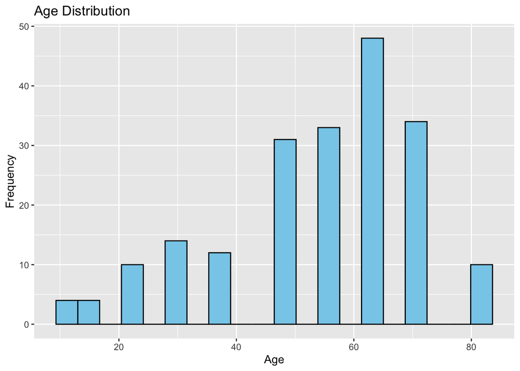

```r
library(ggplot2)

# Distribution of continuous variables
ggplot(df, aes(x = age)) +
  geom_histogram(bins = 20, fill = "skyblue", color = "black") +
  labs(title = "Age Distribution", x = "Age", y = "Frequency")
```

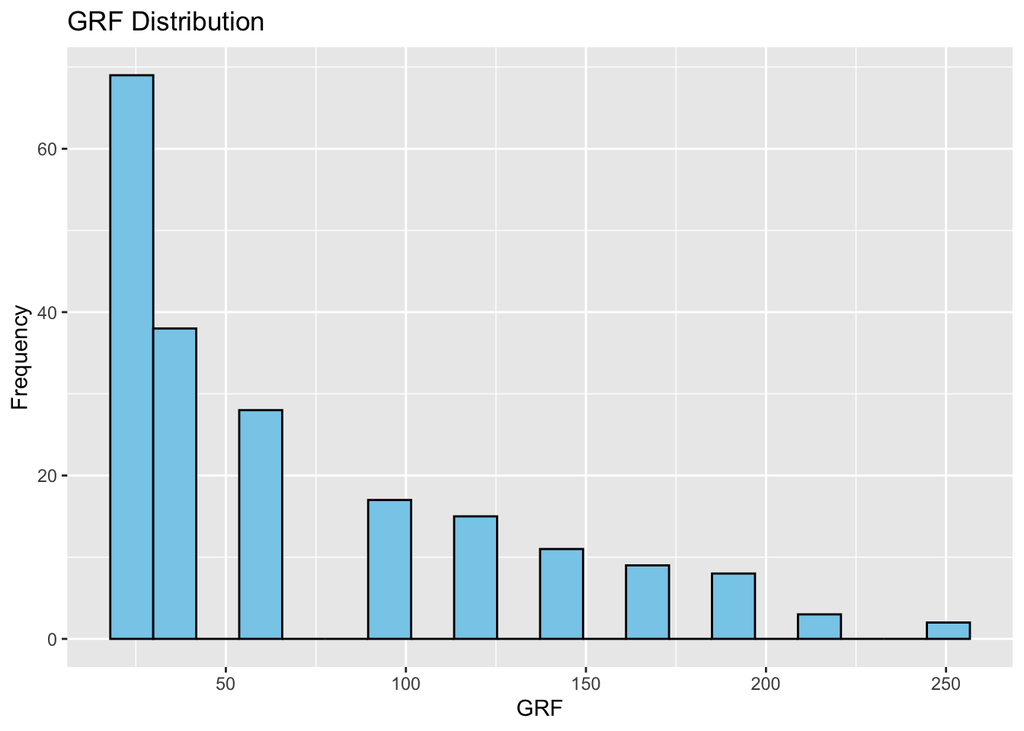

```r
ggplot(df, aes(x = grf)) +
  geom_histogram(bins = 20, fill = "skyblue", color = "black") +
  labs(title = "GRF Distribution", x = "GRF", y = "Frequency")
```

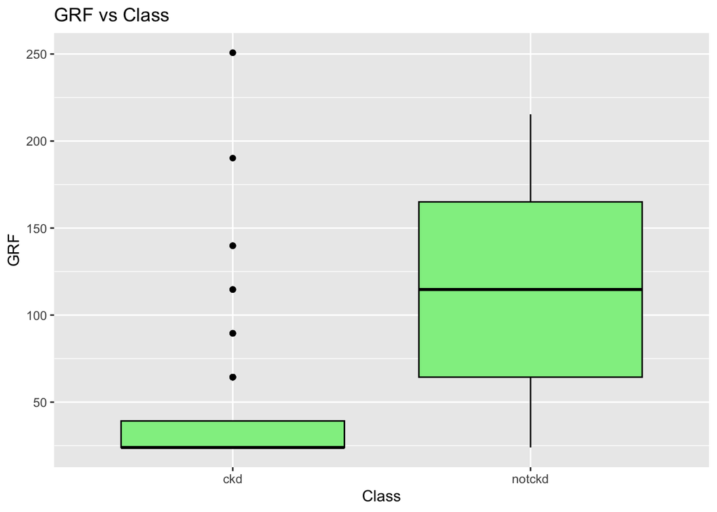

```r
# Boxplot for detecting outliers in continuous features
ggplot(df, aes(x = class, y = grf)) +
  geom_boxplot(fill = "lightgreen", color = "black") +
  labs(title = "GRF vs Class", x = "Class", y = "GRF")
```

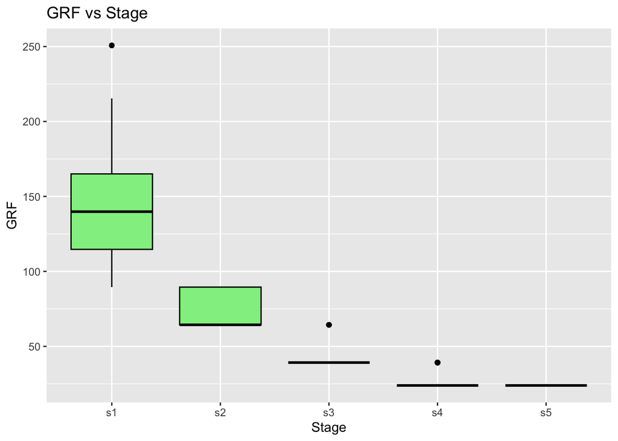

```r
ggplot(df, aes(x = stage, y = grf)) +
  geom_boxplot(fill = "lightgreen", color = "black") +
  labs(title = "GRF vs Stage", x = "Stage", y = "GRF")
```

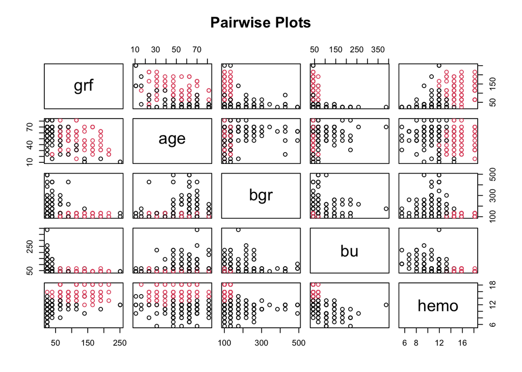

```r
# Pairwise relationships between continuous variables
pairs(df[, c("grf", "age", "bgr", "bu", "hemo")],
      main = "Pairwise Plots",
      col = df$class)
```

From the exploratory data plots, we can intrepret the following:

The GRF vs Stage box-plot demonstrates a clear negative correlation between disease stage and kidney function (GRF). Stage 1 patients maintain the highest GRF values (around 140), while stages 3-5 show significantly lower values (below 50). This indicates progressive deterioration of kidney function with advancing disease which is logical observation.

The pairwise plot tells us the following:

Hemoglobin (hemo) levels decline as kidney function (GRF) decreases.

Two distinct clusters (black and pink) indicate a clear separation between disease classes.

```r
continuous_cols <- c("sg", "al", "su", "bgr", "bu", "sod", "sc", "pot",
                     "hemo", "pcv", "rbcc", "wbcc", "grf", "age")

detect_outliers <- function(df) {
  outlier_summary <- lapply(df[, continuous_cols], function(x) {
    Q1 <- quantile(x, 0.25, na.rm = TRUE)
    Q3 <- quantile(x, 0.75, na.rm = TRUE)
    IQR <- Q3 - Q1
    lower_bound <- Q1 - 1.5 * IQR
    upper_bound <- Q3 + 1.5 * IQR

    outliers <- x[x < lower_bound | x > upper_bound]
    list(
      num_outliers = length(outliers),
      percent_outliers = (length(outliers) / length(x)) * 100,
      lower_bound = lower_bound,
      upper_bound = upper_bound
    )
  })

  return(outlier_summary)
}
outlier_summary <- detect_outliers(df)

outlier_summary
```

```
## $sg
## $sg$num_outliers
## [1] 89
##
## $sg$percent_outliers
## [1] 44.5
##
## $sg$lower_bound
##  25%
## 1.01
##
## $sg$upper_bound
##   75%
## 1.026
##
##
## $al
## $al$num_outliers
## [1] 0
##
## $al$percent_outliers
## [1] 0
##
## $al$lower_bound
## 25%
##  -3
##
## $al$upper_bound
## 75%
##   5
##
##
## $su
## $su$num_outliers
## [1] 30
##
## $su$percent_outliers
## [1] 15
##
## $su$lower_bound
```

[output cut: 167 more lines]

```
##
## $age
## $age$num_outliers
## [1] 18
##
## $age$percent_outliers
## [1] 9
##
## $age$lower_bound
##   25%
## 23.75
##
## $age$upper_bound
##   75%
## 85.75
```

From the outlier analysis on continuous variables, we can determine a few things. al, hemo, and pcv have no outliers. 44.5% of sg values are flagged as outliers, which is significant. This is due to specific gravity having a naturally narrow range, making the IQR method overly sensitive. sc (20.5%) and bu (19.5%) show considerable outlier presence. su (15%), sod (11.5%), and wbcc (8%) have moderate outlier presence. sc and pot have identical lower and upper bounds, indicating near-zero IQR, so the method flags almost any variation. bgr has an unusually high upper bound of 286.3 whereas grf has a lower bound of -74.4, suggesting unrealistic values. This tells us that we are going to need robust transformation to the data which we will implement later

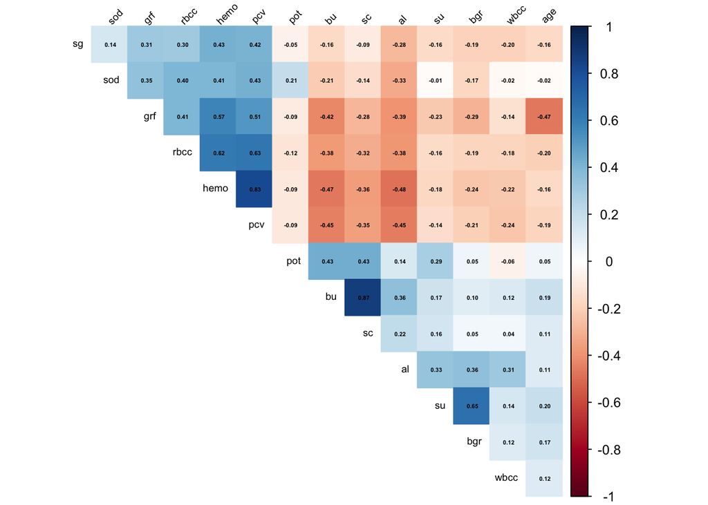

```
## $correlation_matrix
##               sg         al         su         bgr         bu         sod
## sg    1.00000000 -0.2778450 -0.1562781 -0.19464018 -0.1643114  0.14305835
## al   -0.27784502  1.0000000  0.3326176  0.35874840  0.3569880 -0.32512040
## su   -0.15627813  0.3326176  1.0000000  0.65219464  0.1729086 -0.01382720
## bgr  -0.19464018  0.3587484  0.6521946  1.00000000  0.1049624 -0.17013489
## bu   -0.16431141  0.3569880  0.1729086  0.10496244  1.0000000 -0.21191588
## sod   0.14305835 -0.3251204 -0.0138272 -0.17013489 -0.2119159  1.00000000
## sc   -0.08699706  0.2194487  0.1580649  0.04678552  0.8711514 -0.14012709
## pot  -0.05261955  0.1384378  0.2871571  0.05284273  0.4335572  0.20790060
## hemo  0.42622374 -0.4814478 -0.1796031 -0.23566685 -0.4691039  0.40809394
## pcv   0.41688908 -0.4546970 -0.1443059 -0.20639803 -0.4452265  0.42778908
## rbcc  0.30304381 -0.3803471 -0.1567896 -0.18550190 -0.3790572  0.40128726
## wbcc -0.19825477  0.3146932  0.1444273  0.11668420  0.1236913 -0.02419474
## grf   0.31039434 -0.3937687 -0.2265416 -0.29351949 -0.4230880  0.34882756
## age  -0.16204177  0.1109364  0.1967573  0.16690603  0.1857953 -0.01902258
##               sc         pot        hemo         pcv       rbcc        wbcc
## sg   -0.08699706 -0.05261955  0.42622374  0.41688908  0.3030438 -0.19825477
## al    0.21944870  0.13843781 -0.48144779 -0.45469696 -0.3803471  0.31469319
## su    0.15806495  0.28715714 -0.17960311 -0.14430587 -0.1567896  0.14442733
## bgr   0.04678552  0.05284273 -0.23566685 -0.20639803 -0.1855019  0.11668420
## bu    0.87115137  0.43355716 -0.46910387 -0.44522648 -0.3790572  0.12369132
## sod  -0.14012709  0.20790060  0.40809394  0.42778908  0.4012873 -0.02419474
## sc    1.00000000  0.43392899 -0.36066547 -0.35236446 -0.3152179  0.04014702
## pot   0.43392899  1.00000000 -0.09233173 -0.09227341 -0.1177813 -0.05689994
## hemo -0.36066547 -0.09233173  1.00000000  0.82701688  0.6157502 -0.22488688
## pcv  -0.35236446 -0.09227341  0.82701688  1.00000000  0.6332710 -0.23914821
## rbcc -0.31521786 -0.11778131  0.61575016  0.63327098  1.0000000 -0.18238724
## wbcc  0.04014702 -0.05689994 -0.22488688 -0.23914821 -0.1823872  1.00000000
## grf  -0.28241667 -0.08634383  0.57470293  0.51105375  0.4075050 -0.13573262
## age   0.11209256  0.05271670 -0.16274831 -0.18734302 -0.2008799  0.11727569
##              grf         age
## sg    0.31039434 -0.16204177
## al   -0.39376871  0.11093643
## su   -0.22654155  0.19675733
## bgr  -0.29351949  0.16690603
## bu   -0.42308804  0.18579534
## sod   0.34882756 -0.01902258
## sc   -0.28241667  0.11209256
## pot  -0.08634383  0.05271670
## hemo  0.57470293 -0.16274831
## pcv   0.51105375 -0.18734302
## rbcc  0.40750503 -0.20087986
## wbcc -0.13573262  0.11727569
## grf   1.00000000 -0.46995749
## age  -0.46995749  1.00000000
##
## $highly_correlated_features
## [1] "hemo" "bu"
```

```r
library(corrplot)
library(caret)

correlation_analysis <- function(df) {

  numeric_df <- df[, continuous_cols]

  cor_matrix <- cor(numeric_df, use = "complete.obs")

  # highly correlated features (correlation > 0.7)
  high_cor <- findCorrelation(cor_matrix, cutoff = 0.7)

  corrplot(cor_matrix,
           method = "color",
           type = "upper",
           addCoef.col = "black",
           tl.col = "black",
           tl.srt = 45,
           tl.cex = 0.6,
           diag = FALSE,
           order = "hclust",
           number.cex = 0.35)
  return(list(
    correlation_matrix = cor_matrix,
    highly_correlated_features = colnames(numeric_df)[high_cor]
  ))
}

correlation_analysis(df)
```

In this chunk, I performed collinearity analysis by using a correlation matrix and a corrplot on continuous variables only. The highly correlated pairs (above 0.7 cutoff) are hemo and pcv (0.83) and bu and sc (0.87). grf shows moderate negative correlations with bu (-0.42), sc (-0.28), and al (-0.39), which is clinically expected as declining kidney function leads to elevated blood urea and serum creatinine

```r
df <- df[, !(names(df) %in% c("pcv", "sc", "affected", "stage"))]

continuous_cols <- c("sg", "al", "su", "bgr", "bu", "sod", "pot",
                     "hemo", "rbcc", "wbcc", "grf", "age")
```

I removed pcv and sc to reduce multicollinearity (pcv-hemo: 0.83, sc-bu: 0.87), affected because it perfectly maps to the target variable (data leakage), and stage because it is derived from GRF and nearly perfectly separates the classes. This retains the same clinical information through raw biomarkers

```r
# Convert categorical variables to factors
cat_vars <- c("rbc", "pc", "pcc", "ba", "htn", "dm", "cad", "appet", "pe", "ane")
df[cat_vars] <- lapply(df[cat_vars], as.factor)

chi_squared_analysis <- function(df) {
  cat_cols <- sapply(df, is.factor)
  cat_df <- df[, cat_cols]

  chi_results <- lapply(names(cat_df)[names(cat_df) != "class"], function(col) {
    contingency_table <- table(cat_df[[col]], df$class)
    chi_test <- chisq.test(contingency_table)
    return(list(
      feature = col,
      chi_squared = chi_test$statistic,
      p_value = chi_test$p.value
    ))
  })

  return(do.call(rbind, chi_results))
}

chi_squared_analysis(df)
```

```
## Warning in chisq.test(contingency_table): Chi-squared approximation may be
## incorrect
```

```
##       feature chi_squared p_value
##  [1,] "rbc"   14.33532    0.000152968
##  [2,] "pc"    30.67627    3.048702e-08
##  [3,] "pcc"   15.7979     7.048051e-05
##  [4,] "ba"    4.998564    0.02536836
##  [5,] "htn"   69.38756    8.089733e-17
##  [6,] "dm"    58.19692    2.371495e-14
##  [7,] "cad"   12.20429    0.0004767965
##  [8,] "appet" 26.20578    3.06902e-07
##  [9,] "pe"    22.00728    2.71619e-06
## [10,] "ane"   19.60882    9.502952e-06
```

All categorical variables showed statistically significant association with class (all p-values below 0.05). htn had the strongest association (69.4), followed by dm (58.2). ba had the weakest association (5.0, p = 0.025). The warning about chi-squared approximation is due to low expected counts in some contingency table cells, particularly for sparse variables like ba.

```r
evaluate_distribution <- function(df) {
  normality_tests <- lapply(df[, continuous_cols], function(x) {
    test <- shapiro.test(x)
    return(list(
      statistic = test$statistic,
      p_value = test$p.value
    ))
  })

  return(normality_tests)
}

evaluate_distribution(df)
```

```
## $sg
## $sg$statistic
##         W
## 0.6303511
##
## $sg$p_value
## [1] 1.399488e-20
##
##
## $al
## $al$statistic
##         W
## 0.7299977
##
## $al$p_value
## [1] 9.186653e-18
##
##
## $su
## $su$statistic
##        W
## 0.437752
##
## $su$p_value
## [1] 1.08371e-24
##
##
## $bgr
## $bgr$statistic
##         W
## 0.6618947
##
## $bgr$p_value
## [1] 9.304925e-20
##
##
## $bu
## $bu$statistic
##         W
## 0.6125643
```

[output cut: 51 more lines]

```
## $grf$statistic
##         W
## 0.8047944
##
## $grf$p_value
## [1] 4.337868e-15
##
##
## $age
## $age$statistic
##         W
## 0.9317398
##
## $age$p_value
## [1] 4.654158e-08
```

In this chunk, I use the shapiro-wilk to check the distribution of the data. In this, a W statistic closer to “1” implies that the data may be normally distributed while low p-value (less than 0.05) indicates that the data does not follow a normal distribution. All the variables have extremely low p values indicating a non-normal distribution.

```r
numeric_df <- df[, continuous_cols]

preprocess_model <- preProcess(numeric_df,
                               method = c("BoxCox", "center", "scale"))

df[, continuous_cols] <- predict(preprocess_model, numeric_df)

head(df)
```

|  | bp..Diastolic. | bp.limit | sg | al | class | rbc | su | pc | pcc | ba | bgr | bu | sod | pot | hemo | rbcc | wbcc | htn | dm | cad | appet | pe | ane | grf | age |
| --- | --- | --- | --- | --- | --- | --- | --- | --- | --- | --- | --- | --- | --- | --- | --- | --- | --- | --- | --- | --- | --- | --- | --- | --- | --- |
| 1 | 0 | 0 | -0.3184797 | -0.004312148 | ckd | 0 | -0.3895085 | 0 | 0 | 0 | -1.1590689 | -0.8754022 | 0.4173874 | -0.1190789 | -0.1252040 | 0.02714689 | 0.1417209 | 0 | 0 | 0 | 0 | 0 | 0 | 1.778406 | -2.119211 |
| 2 | 0 | 0 | -0.5560856 | -0.723003408 | ckd | 0 | -0.3895085 | 0 | 0 | 0 | 0.1334644 | -0.8754022 | -0.2593336 | -0.1190789 | -0.1252040 | 0.02714689 | 1.5170626 | 0 | 0 | 0 | 0 | 0 | 0 | 1.778406 | -2.119211 |
| 3 | 0 | 0 | -0.5560856 | 2.439238137 | ckd | 1 | -0.3895085 | 1 | 0 | 1 | -1.1590689 | 0.6490495 | -0.2593336 | -0.1190789 | -1.0090772 | 0.02714689 | 1.9693156 | 0 | 0 | 0 | 1 | 0 | 0 | 1.284511 | -2.119211 |
| 4 | 1 | 1 | -0.5560856 | 1.433070373 | ckd | 0 | -0.3895085 | 0 | 0 | 0 | 0.1334644 | -0.8754022 | -0.2593336 | -0.1190789 | 0.7586691 | 0.02714689 | 0.1417209 | 0 | 0 | 0 | 0 | 0 | 0 | 1.284511 | -2.119211 |
| 5 | 0 | 0 | -0.4126805 | -0.723003408 | ckd | 0 | -0.3895085 | 0 | 0 | 0 | 0.9121551 | -0.8754022 | -0.2593336 | -0.1190789 | 0.7586691 | 0.70011591 | 0.1417209 | 0 | 1 | 0 | 1 | 1 | 0 | 1.284511 | -1.971599 |
| 6 | 1 | 1 | 1.8115399 | -0.723003408 | notckd | 0 | -0.3895085 | 0 | 0 | 0 | -1.1590689 | -0.8754022 | -0.2593336 | -0.1190789 | 1.9824935 | 0.70011591 | -1.0398545 | 0 | 0 | 0 | 0 | 0 | 0 | 1.088655 | -1.971599 |

```r
str(df)
```

```
## 'data.frame':    200 obs. of  25 variables:
##  $ bp..Diastolic.: num  0 0 0 1 0 1 0 0 0 1 ...
##  $ bp.limit      : num  0 0 0 1 0 1 0 0 0 2 ...
##  $ sg            : num  -0.318 -0.556 -0.556 -0.556 -0.413 ...
##  $ al            : num  -0.00431 -0.723 2.43924 1.43307 -0.723 ...
##  $ class         : Factor w/ 2 levels "ckd","notckd": 1 1 1 1 1 2 1 1 2 1 ...
##  $ rbc           : Factor w/ 2 levels "0","1": 1 1 2 1 1 1 1 1 1 1 ...
##  $ su            : num  -0.39 -0.39 -0.39 -0.39 -0.39 ...
##  $ pc            : Factor w/ 2 levels "0","1": 1 1 2 1 1 1 1 1 1 2 ...
##  $ pcc           : Factor w/ 2 levels "0","1": 1 1 1 1 1 1 1 1 1 2 ...
##  $ ba            : Factor w/ 2 levels "0","1": 1 1 2 1 1 1 1 1 1 2 ...
##  $ bgr           : num  -1.159 0.133 -1.159 0.133 0.912 ...
##  $ bu            : num  -0.875 -0.875 0.649 -0.875 -0.875 ...
##  $ sod           : num  0.417 -0.259 -0.259 -0.259 -0.259 ...
##  $ pot           : num  -0.119 -0.119 -0.119 -0.119 -0.119 ...
##  $ hemo          : num  -0.125 -0.125 -1.009 0.759 0.759 ...
##  $ rbcc          : num  0.0271 0.0271 0.0271 0.0271 0.7001 ...
##  $ wbcc          : num  0.142 1.517 1.969 0.142 0.142 ...
##  $ htn           : Factor w/ 2 levels "0","1": 1 1 1 1 1 1 2 1 1 1 ...
##  $ dm            : Factor w/ 2 levels "0","1": 1 1 1 1 2 1 2 1 1 1 ...
##  $ cad           : Factor w/ 2 levels "0","1": 1 1 1 1 1 1 1 1 1 1 ...
##  $ appet         : Factor w/ 2 levels "0","1": 1 1 2 1 2 1 1 1 1 1 ...
##  $ pe            : Factor w/ 2 levels "0","1": 1 1 1 1 2 1 1 1 1 1 ...
##  $ ane           : Factor w/ 2 levels "0","1": 1 1 1 1 1 1 1 1 1 2 ...
##  $ grf           : num  1.78 1.78 1.28 1.28 1.28 ...
##  $ age           : num  -2.12 -2.12 -2.12 -2.12 -1.97 ...
```

In this chunk, I used Box-Cox transformation to center and scale the 12 continuous features (sg, al, su, bgr, bu, sod, pot, hemo, rbcc, wbcc, grf, age). Binary and categorical variables were excluded from transformation as centering and scaling are not meaningful for them

```r
pca_result <- prcomp(df[, continuous_cols], center = TRUE, scale. = TRUE)

# Check variance explained
variance_explained <- cumsum(pca_result$sdev^2 / sum(pca_result$sdev^2))
num_components <- which(variance_explained >= 0.95)[1]

cat("Components needed for 95% variance:", num_components, "\n")
```

```
## Components needed for 95% variance: 10
```

```r
# Build PCA dataframe with selected components
pca_df <- as.data.frame(pca_result$x[, 1:num_components])

# Add back categorical variables and target
cat_vars <- c("rbc", "pc", "pcc", "ba", "htn", "dm", "cad", "appet",
              "pe", "ane", "bp..Diastolic.", "bp.limit")
pca_df <- cbind(pca_df, df[, cat_vars], class = df$class)
```

I performed PCA on the 12 continuous features. 10 components are needed to explain 95% of the variance. Categorical variables were excluded from PCA and added back to the PCA dataframe alongside the principal components for use in modeling

```r
set.seed(123)
train_index <- createDataPartition(pca_df$class, p = 0.75, list = FALSE)
train_data <- pca_df[train_index, ]
test_data <- pca_df[-train_index, ]
```

I chose to split the data in a 75:25 as it is very common and is appropriate for this data-set.

```r
# Logistic regression with K-fold Cross Validation
cv_control <- trainControl(method = "cv", number = 10) # 10-fold cross-validation

logistic_model_cv <- train(class ~ .,
                           data = train_data,
                           method = "glmnet",
                           family = "binomial",
                           trControl = cv_control)

print(logistic_model_cv)
```

```
## glmnet
##
## 150 samples
##  22 predictor
##   2 classes: 'ckd', 'notckd'
##
## No pre-processing
## Resampling: Cross-Validated (10 fold)
## Summary of sample sizes: 134, 135, 135, 135, 134, 135, ...
## Resampling results across tuning parameters:
##
##   alpha  lambda        Accuracy   Kappa
##   0.10   0.0007812995  0.9599405  0.9148552
##   0.10   0.0078129949  0.9599405  0.9187870
##   0.10   0.0781299490  0.9457143  0.8928571
##   0.55   0.0007812995  0.9599405  0.9148552
##   0.55   0.0078129949  0.9661905  0.9316902
##   0.55   0.0781299490  0.9466667  0.8892359
##   1.00   0.0007812995  0.9595238  0.9134728
##   1.00   0.0078129949  0.9533333  0.9010936
##   1.00   0.0781299490  0.9537500  0.9011774
##
## Accuracy was used to select the optimal model using the largest value.
## The final values used for the model were alpha = 0.55 and lambda = 0.007812995.
```

```r
logistic_pred_cv <- predict(logistic_model_cv, test_data)

# Confusion matrix
conf_matrix_logistic <- confusionMatrix(logistic_pred_cv, test_data$class)
print(conf_matrix_logistic)
```

```
## Confusion Matrix and Statistics
##
##           Reference
## Prediction ckd notckd
##     ckd     30      1
##     notckd   2     17
##
##                Accuracy : 0.94
##                  95% CI : (0.8345, 0.9875)
##     No Information Rate : 0.64
##     P-Value [Acc > NIR] : 7.955e-07
##
##                   Kappa : 0.8714
##
##  Mcnemar's Test P-Value : 1
##
##             Sensitivity : 0.9375
##             Specificity : 0.9444
##          Pos Pred Value : 0.9677
##          Neg Pred Value : 0.8947
##              Prevalence : 0.6400
##          Detection Rate : 0.6000
##    Detection Prevalence : 0.6200
##       Balanced Accuracy : 0.9410
##
##        'Positive' Class : ckd
##
```

```r
accuracy_logistic <- conf_matrix_logistic$overall['Accuracy']
precision_logistic <- conf_matrix_logistic$byClass['Pos Pred Value']
recall_logistic <- conf_matrix_logistic$byClass['Sensitivity']
f1_score_logistic <- 2 * ((precision_logistic * recall_logistic) / (precision_logistic + recall_logistic))

cat("Logistic Regression Accuracy: ", accuracy_logistic, "\n")
```

```
## Logistic Regression Accuracy:  0.94
```

```r
cat("Logistic Regression F1-Score: ", f1_score_logistic, "\n")
```

```
## Logistic Regression F1-Score:  0.952381
```

The model correctly identifies 30 true positives (ckd) and 17 true negatives (notckd), with only 2 false negatives and 1 false positive. The accuracy of 94% is statistically significant compared to the No Information Rate (NIR = 0.64), confirmed by a p-value of 7.955e-07. The F1 score of 0.95 indicates strong balance between precision and recall

```r
rf_model <- train(class ~ ., data = train_data, method = "rf",
                  trControl = trainControl(method = "cv", number = 10),
                  tuneGrid = expand.grid(mtry = c(2, 5, 10)))

print(rf_model)
```

```
## Random Forest
##
## 150 samples
##  22 predictor
##   2 classes: 'ckd', 'notckd'
##
## No pre-processing
## Resampling: Cross-Validated (10 fold)
## Summary of sample sizes: 134, 135, 135, 134, 136, 135, ...
## Resampling results across tuning parameters:
##
##   mtry  Accuracy   Kappa
##    2    0.9727976  0.9407485
##    5    0.9799405  0.9556421
##   10    0.9732738  0.9413564
##
## Accuracy was used to select the optimal model using the largest value.
## The final value used for the model was mtry = 5.
```

```r
rf_pred <- predict(rf_model, newdata = test_data)

conf_matrix_rf <- confusionMatrix(rf_pred, test_data$class)
print(conf_matrix_rf)
```

```
## Confusion Matrix and Statistics
##
##           Reference
## Prediction ckd notckd
##     ckd     30      2
##     notckd   2     16
##
##                Accuracy : 0.92
##                  95% CI : (0.8077, 0.9778)
##     No Information Rate : 0.64
##     P-Value [Acc > NIR] : 5.492e-06
##
##                   Kappa : 0.8264
##
##  Mcnemar's Test P-Value : 1
##
##             Sensitivity : 0.9375
##             Specificity : 0.8889
##          Pos Pred Value : 0.9375
##          Neg Pred Value : 0.8889
##              Prevalence : 0.6400
##          Detection Rate : 0.6000
##    Detection Prevalence : 0.6400
##       Balanced Accuracy : 0.9132
##
##        'Positive' Class : ckd
##
```

```r
accuracy_rf <- conf_matrix_rf$overall['Accuracy']
precision_rf <- conf_matrix_rf$byClass['Pos Pred Value']
recall_rf <- conf_matrix_rf$byClass['Sensitivity']
f1_score_rf <- 2 * ((precision_rf * recall_rf) / (precision_rf + recall_rf))

cat("Random Forest Accuracy: ", accuracy_rf, "\n")
```

```
## Random Forest Accuracy:  0.92
```

```r
cat("Random Forest F1-Score: ", f1_score_rf, "\n")
```

```
## Random Forest F1-Score:  0.9375
```

Random Forest with 10-fold cross-validation selected mtry = 5 as optimal. The model achieves 92% accuracy with an F1 score of 0.94. It correctly identifies 30 true positives and 16 true negatives, with 2 false positives and 2 false negatives. Cross-validation accuracy peaked at 98% for mtry = 5, suggesting the model generalizes well.

```r
# SVM with K-fold Cross Validation
svm_model <- train(class ~ .,
                   data = train_data,
                   method = "svmLinear",
                   trControl = trainControl(method = "cv", number = 10),
                   tuneLength = 5)

print(svm_model)
```

```
## Support Vector Machines with Linear Kernel
##
## 150 samples
##  22 predictor
##   2 classes: 'ckd', 'notckd'
##
## No pre-processing
## Resampling: Cross-Validated (10 fold)
## Summary of sample sizes: 134, 134, 134, 136, 135, 136, ...
## Resampling results:
##
##   Accuracy   Kappa
##   0.9527381  0.9006908
##
## Tuning parameter 'C' was held constant at a value of 1
```

```r
# Predictions
svm_pred <- predict(svm_model, test_data)

# Confusion matrix
conf_matrix_svm <- confusionMatrix(svm_pred, test_data$class)
print(conf_matrix_svm)
```

```
## Confusion Matrix and Statistics
##
##           Reference
## Prediction ckd notckd
##     ckd     28      0
##     notckd   4     18
##
##                Accuracy : 0.92
##                  95% CI : (0.8077, 0.9778)
##     No Information Rate : 0.64
##     P-Value [Acc > NIR] : 5.492e-06
##
##                   Kappa : 0.8344
##
##  Mcnemar's Test P-Value : 0.1336
##
##             Sensitivity : 0.8750
##             Specificity : 1.0000
##          Pos Pred Value : 1.0000
##          Neg Pred Value : 0.8182
##              Prevalence : 0.6400
##          Detection Rate : 0.5600
##    Detection Prevalence : 0.5600
##       Balanced Accuracy : 0.9375
##
##        'Positive' Class : ckd
##
```

```r
# Accuracy and F1-Score
accuracy_svm <- conf_matrix_svm$overall['Accuracy']
precision_svm <- conf_matrix_svm$byClass['Pos Pred Value']
recall_svm <- conf_matrix_svm$byClass['Sensitivity']
f1_score_svm <- 2 * ((precision_svm * recall_svm) / (precision_svm + recall_svm))

cat("SVM Accuracy: ", accuracy_svm, "\n")
```

```
## SVM Accuracy:  0.92
```

```r
cat("SVM F1-Score: ", f1_score_svm, "\n")
```

```
## SVM F1-Score:  0.9333333
```

```r
# Hyperparameter tuning for SVM
svm_tune_grid <- expand.grid(C = c(0.1, 1, 10), # Cost values to test
                             sigma = c(0.01, 0.1, 1))  # Sigma values for radial kernel

svm_tuned <- train(class ~ .,
                   data = train_data,
                   method = "svmRadial",
                   trControl = trainControl(method = "cv", number = 10),
                   tuneGrid = svm_tune_grid)

print(svm_tuned)
```

```
## Support Vector Machines with Radial Basis Function Kernel
##
## 150 samples
##  22 predictor
##   2 classes: 'ckd', 'notckd'
##
## No pre-processing
## Resampling: Cross-Validated (10 fold)
## Summary of sample sizes: 135, 135, 134, 136, 136, 135, ...
## Resampling results across tuning parameters:
##
##   C     sigma  Accuracy   Kappa
##    0.1  0.01   0.6403571  0.0000000
##    0.1  0.10   0.7932143  0.4976422
##    0.1  1.00   0.6403571  0.0000000
##    1.0  0.01   0.9339881  0.8678986
##    1.0  0.10   0.9460119  0.8835895
##    1.0  1.00   0.7072024  0.2189345
##   10.0  0.01   0.9535714  0.9058826
##   10.0  0.10   0.9398214  0.8714568
##   10.0  1.00   0.7272024  0.2880522
##
## Accuracy was used to select the optimal model using the largest value.
## The final values used for the model were sigma = 0.01 and C = 10.
```

SVM with linear kernel achieves 92% accuracy and an F1 score of 0.93 using 10-fold cross-validation. The model has perfect specificity (no false positives) but misses 4 CKD cases (false negatives), suggesting it is conservative in predicting CKD.

```r
# Tuned SVM predictions
svm_tuned_pred <- predict(svm_tuned, test_data)

conf_matrix_svm_tuned <- confusionMatrix(svm_tuned_pred, test_data$class)
print(conf_matrix_svm_tuned)
```

```
## Confusion Matrix and Statistics
##
##           Reference
## Prediction ckd notckd
##     ckd     29      0
##     notckd   3     18
##
##                Accuracy : 0.94
##                  95% CI : (0.8345, 0.9875)
##     No Information Rate : 0.64
##     P-Value [Acc > NIR] : 7.955e-07
##
##                   Kappa : 0.8744
##
##  Mcnemar's Test P-Value : 0.2482
##
##             Sensitivity : 0.9062
##             Specificity : 1.0000
##          Pos Pred Value : 1.0000
##          Neg Pred Value : 0.8571
##              Prevalence : 0.6400
##          Detection Rate : 0.5800
##    Detection Prevalence : 0.5800
##       Balanced Accuracy : 0.9531
##
##        'Positive' Class : ckd
##
```

```r
accuracy_svm_tuned <- conf_matrix_svm_tuned$overall['Accuracy']
precision_svm_tuned <- conf_matrix_svm_tuned$byClass['Pos Pred Value']
recall_svm_tuned <- conf_matrix_svm_tuned$byClass['Sensitivity']
f1_score_svm_tuned <- 2 * ((precision_svm_tuned * recall_svm_tuned) / (precision_svm_tuned + recall_svm_tuned))

cat("Tuned SVM Accuracy: ", accuracy_svm_tuned, "\n")
```

```
## Tuned SVM Accuracy:  0.94
```

```r
cat("Tuned SVM F1-Score: ", f1_score_svm_tuned, "\n")
```

```
## Tuned SVM F1-Score:  0.9508197
```

```r
comparison_results <- data.frame(
  Model = c("Logistic Regression", "Random Forest", "SVM Linear", "SVM Radial (Tuned)"),
  Accuracy = c(accuracy_logistic, accuracy_rf, accuracy_svm, accuracy_svm_tuned),
  F1_Score = c(f1_score_logistic, f1_score_rf, f1_score_svm, f1_score_svm_tuned)
)
comparison_results
```

| Model | Accuracy | F1_Score |
| --- | --- | --- |
| Logistic Regression | 0.94 | 0.9523810 |
| Random Forest | 0.92 | 0.9375000 |
| SVM Linear | 0.92 | 0.9333333 |
| SVM Radial (Tuned) | 0.94 | 0.9508197 |

The comparison table summarizes accuracy and F1 scores across all models. Logistic Regression and Tuned SVM Radial both achieve the highest test accuracy at 94%, while Random Forest and Linear SVM both score 92%.

```r
# Predictions from existing models
pred_logistic <- predict(logistic_model_cv, test_data)
pred_rf <- predict(rf_model, test_data)
pred_svm <- predict(svm_tuned, test_data)

# Majority voting
votes <- data.frame(pred_logistic, pred_rf, pred_svm)
ensemble_pred <- apply(votes, 1, function(row) {
  names(sort(table(row), decreasing = TRUE))[1]
})
ensemble_pred <- factor(ensemble_pred, levels = c("ckd", "notckd"))

# Evaluation
ensemble_cm <- confusionMatrix(ensemble_pred, test_data$class)
print(ensemble_cm)
```

```
## Confusion Matrix and Statistics
##
##           Reference
## Prediction ckd notckd
##     ckd     30      1
##     notckd   2     17
##
##                Accuracy : 0.94
##                  95% CI : (0.8345, 0.9875)
##     No Information Rate : 0.64
##     P-Value [Acc > NIR] : 7.955e-07
##
##                   Kappa : 0.8714
##
##  Mcnemar's Test P-Value : 1
##
##             Sensitivity : 0.9375
##             Specificity : 0.9444
##          Pos Pred Value : 0.9677
##          Neg Pred Value : 0.8947
##              Prevalence : 0.6400
##          Detection Rate : 0.6000
##    Detection Prevalence : 0.6200
##       Balanced Accuracy : 0.9410
##
##        'Positive' Class : ckd
##
```

```r
accuracy_ensemble <- ensemble_cm$overall['Accuracy']
precision_ensemble <- ensemble_cm$byClass['Pos Pred Value']
recall_ensemble <- ensemble_cm$byClass['Sensitivity']
f1_ensemble <- 2 * ((precision_ensemble * recall_ensemble) / (precision_ensemble + recall_ensemble))

cat("Ensemble Accuracy: ", accuracy_ensemble, "\n")
```

```
## Ensemble Accuracy:  0.94
```

```r
cat("Ensemble F1-Score: ", f1_ensemble, "\n")
```

```
## Ensemble F1-Score:  0.952381
```

```r
comparison_results <- rbind(
  comparison_results,
  data.frame(
    Model = "Ensemble (Majority Vote)",
    Accuracy = accuracy_ensemble,
    F1_Score = f1_ensemble
  )
)
print(comparison_results)
```

```
##                             Model Accuracy  F1_Score
## 1             Logistic Regression     0.94 0.9523810
## 2                   Random Forest     0.92 0.9375000
## 3                      SVM Linear     0.92 0.9333333
## 4              SVM Radial (Tuned)     0.94 0.9508197
## Accuracy Ensemble (Majority Vote)     0.94 0.9523810
```